# Homework 4

Chris Cavan

Stat 170

## 1.) Start with a model that predicts your Y variable with all other variables in your dataset as explanatory variables. We will call this model1.

```r
d2 = na.omit(read.csv(choose.files(), header = T))
attach(d2)
model1 = lm(debt ~ region + type + state + admit + ratio + grad + cost + need + noneed)
```

## 1a(i). Do stepwise regression on model1. Write out the model that stepwise regression chooses.

```r
# null model
m0 = lm(debt~1)
summary(m0)
```

```
##
## Call:
## lm(formula = debt ~ 1)
##
## Residuals:
##      Min       1Q   Median       3Q      Max
## -20106.4  -4002.4     52.6   4042.1  18925.6
##
## Coefficients:
##             Estimate Std. Error t value Pr(>|t|)
## (Intercept)  25658.4      353.7   72.55   <2e-16 ***
## ---
## Signif. codes:  0 '***' 0.001 '**' 0.01 '*' 0.05 '.' 0.1 ' ' 1
##
## Residual standard error: 6116 on 298 degrees of freedom
```

```r
# full model is model1
summary(model1)
```

```
##
## Call:
## lm(formula = debt ~ region + type + state + admit + ratio + grad +
##     cost + need + noneed)
##
## Residuals:
##      Min       1Q   Median       3Q      Max
## -18774.3  -2529.6   -303.3   2929.7  18351.0
##
## Coefficients:
##                    Estimate Std. Error t value Pr(>|t|)
## (Intercept)       7.063e+03  4.707e+03   1.500 0.134636
## regionCentral    -9.155e+02  3.344e+03  -0.274 0.784457
## regionNorthern   -1.817e+03  3.295e+03  -0.551 0.581833
## regionPacific    -4.235e+03  3.349e+03  -1.265 0.206974
## regionSouthern   -3.701e+03  3.349e+03  -1.105 0.270034
## regionWestern    -9.727e+02  3.442e+03  -0.283 0.777669
## typePrivate       2.454e+03  7.253e+02   3.383 0.000816 ***
## typePublic       -1.785e+03  1.326e+03  -1.346 0.179518
## stateYes         -9.985e+02  9.902e+02  -1.008 0.314105
## admit             1.052e+02  1.851e+01   5.684 3.26e-08 ***
## ratio             2.899e+02  1.092e+02   2.654 0.008398 **
## grad              6.501e+01  2.764e+01   2.352 0.019350 *
## cost              2.431e-01  5.655e-02   4.299 2.37e-05 ***
## need             -3.071e-01  6.699e-02  -4.585 6.82e-06 ***
## noneed            1.995e-01  4.502e-02   4.431 1.34e-05 ***
## ---
## Signif. codes:  0 '***' 0.001 '**' 0.01 '*' 0.05 '.' 0.1 ' ' 1
##
## Residual standard error: 4551 on 284 degrees of freedom
## Multiple R-squared:  0.4723, Adjusted R-squared:  0.4463
## F-statistic: 18.16 on 14 and 284 DF,  p-value: < 2.2e-16
```

```r
# we use the step function to run through the null model to the full range of the full model.
step(m0, scope=list(lower=m0, upper=model1, direction="both", levels = "0.001"))
```

```
## Start:  AIC=5214.73
## debt ~ 1
##
##          Df  Sum of Sq        RSS    AIC
## + admit   1 1850244842 9.2954e+09 5162.5
## + noneed  1 1514853426 9.6308e+09 5173.0
## + type    2  975656402 1.0170e+10 5191.3
## + region  5  825416267 1.0320e+10 5201.7
## + state   1  216320076 1.0929e+10 5210.9
## + need    1  127464584 1.1018e+10 5213.3
## <none>                 1.1146e+10 5214.7
## + cost    1   41261627 1.1104e+10 5215.6
## + ratio   1    5358633 1.1140e+10 5216.6
## + grad    1    2685456 1.1143e+10 5216.7
##
## Step:  AIC=5162.45
## debt ~ admit
##
##          Df  Sum of Sq        RSS    AIC
## + type    2 1403004483 7.8924e+09 5117.5
## + noneed  1 1317582668 7.9778e+09 5118.7
## + cost    1 1127386105 8.1680e+09 5125.8
## + grad    1  649774801 8.6457e+09 5142.8
## + state   1  228675318 9.0668e+09 5157.0
## + need    1  227410134 9.0680e+09 5157.0
## + region  5  425046336 8.8704e+09 5158.5
## + ratio   1  149788091 9.1456e+09 5159.6
## <none>                 9.2954e+09 5162.5
## - admit   1 1850244842 1.1146e+10 5214.7
##
## Step:  AIC=5117.53
## debt ~ admit + type
##
##          Df  Sum of Sq        RSS    AIC
## + noneed  1  683054724 7.2094e+09 5092.5
## + cost    1  382977809 7.5095e+09 5104.7
## + grad    1  222902913 7.6695e+09 5111.0
## + ratio   1  137654311 7.7548e+09 5114.3
## <none>                 7.8924e+09 5117.5
## + region  5  252058910 7.6404e+09 5117.8
```

[output cut: 80 more lines]

```
## Step:  AIC=5050.65
## debt ~ admit + type + noneed + grad + need + cost + region +
##     ratio
##
##          Df Sum of Sq        RSS    AIC
## <none>                5902180690 5050.6
## + state   1  21058915 5881121775 5051.6
## - grad    1 104267273 6006447963 5053.9
## - ratio   1 147683036 6049863726 5056.0
## - region  5 421749709 6323930399 5061.3
## - cost    1 373733328 6275914018 5067.0
## - noneed  1 405168623 6307349313 5068.5
## - need    1 433788879 6335969569 5069.9
## - type    2 594395731 6496576420 5075.3
## - admit   1 661686566 6563867256 5080.4
```

```
##
## Call:
## lm(formula = debt ~ admit + type + noneed + grad + need + cost +
##     region + ratio)
##
## Coefficients:
##      (Intercept)             admit       typePrivate        typePublic
##        7563.2927          104.5832         2419.0449        -2255.3260
##           noneed              grad              need              cost
##           0.1992           61.5328           -0.3066            0.2399
##    regionCentral    regionNorthern  regionPacific       regionSouthern
##       -1012.4942        -1838.9544        -4394.7769        -3724.3242
##    regionWestern             ratio
##       -1064.3561          291.6624
```

```r
stepwise = lm(debt ~ admit + type + noneed + grad + need + cost +
    region + ratio)
summary(stepwise)
```

```
##
## Call:
## lm(formula = debt ~ admit + type + noneed + grad + need + cost +
##     region + ratio)
##
## Residuals:
##      Min       1Q   Median       3Q      Max
## -18760.0  -2642.1   -312.9   2880.6  18244.8
##
## Coefficients:
##                    Estimate Std. Error t value Pr(>|t|)
## (Intercept)       7.563e+03  4.681e+03   1.616 0.107283
## admit             1.046e+02  1.850e+01   5.653 3.84e-08 ***
## typePrivate       2.419e+03  7.245e+02   3.339 0.000953 ***
## typePublic       -2.255e+03  1.242e+03  -1.816 0.070363 .
## noneed            1.991e-01  4.502e-02   4.423 1.39e-05 ***
## grad              6.153e+01  2.742e+01   2.244 0.025611 *
## need             -3.066e-01  6.699e-02  -4.577 7.06e-06 ***
## cost              2.399e-01  5.646e-02   4.248 2.92e-05 ***
## regionCentral    -1.012e+03  3.343e+03  -0.303 0.762197
## regionNorthern   -1.839e+03  3.296e+03  -0.558 0.577271
## regionPacific    -4.395e+03  3.345e+03  -1.314 0.189942
## regionSouthern   -3.724e+03  3.349e+03  -1.112 0.267095
## regionWestern    -1.064e+03  3.441e+03  -0.309 0.757275
## ratio             2.917e+02  1.092e+02   2.670 0.008010 **
## ---
## Signif. codes:  0 '***' 0.001 '**' 0.01 '*' 0.05 '.' 0.1 ' ' 1
##
## Residual standard error: 4551 on 285 degrees of freedom
## Multiple R-squared:  0.4705, Adjusted R-squared:  0.4463
## F-statistic: 19.48 on 13 and 285 DF,  p-value: < 2.2e-16
```

```r
# forgot to do this step, reattaching d2
attach(d2)
summary(model1)
```

```
##
## Call:
## lm(formula = debt ~ region + type + state + admit + ratio + grad +
##     cost + need + noneed)
##
## Residuals:
##      Min       1Q   Median       3Q      Max
## -18774.3  -2529.6   -303.3   2929.7  18351.0
##
## Coefficients:
##                    Estimate Std. Error t value Pr(>|t|)
## (Intercept)       7.063e+03  4.707e+03   1.500 0.134636
## regionCentral    -9.155e+02  3.344e+03  -0.274 0.784457
## regionNorthern   -1.817e+03  3.295e+03  -0.551 0.581833
## regionPacific    -4.235e+03  3.349e+03  -1.265 0.206974
## regionSouthern   -3.701e+03  3.349e+03  -1.105 0.270034
## regionWestern    -9.727e+02  3.442e+03  -0.283 0.777669
## typePrivate       2.454e+03  7.253e+02   3.383 0.000816 ***
## typePublic       -1.785e+03  1.326e+03  -1.346 0.179518
## stateYes         -9.985e+02  9.902e+02  -1.008 0.314105
## admit             1.052e+02  1.851e+01   5.684 3.26e-08 ***
## ratio             2.899e+02  1.092e+02   2.654 0.008398 **
## grad              6.501e+01  2.764e+01   2.352 0.019350 *
## cost              2.431e-01  5.655e-02   4.299 2.37e-05 ***
## need             -3.071e-01  6.699e-02  -4.585 6.82e-06 ***
## noneed            1.995e-01  4.502e-02   4.431 1.34e-05 ***
## ---
## Signif. codes:  0 '***' 0.001 '**' 0.01 '*' 0.05 '.' 0.1 ' ' 1
##
## Residual standard error: 4551 on 284 degrees of freedom
## Multiple R-squared:  0.4723, Adjusted R-squared:  0.4463
## F-statistic: 18.16 on 14 and 284 DF,  p-value: < 2.2e-16
```

```r
# the largest p-value, 0.784457, is regionCentral. Region contains several categories, thus we must do a partial F test to see whether we keep the region variable as a whole or not.
# we make a model without region
minusRegion = lm(debt ~ type + state + admit + ratio + grad + cost + need + noneed)
anova(minusRegion,model1)
```

```
## Analysis of Variance Table
##
## Model 1: debt ~ type + state + admit + ratio + grad + cost + need + noneed
## Model 2: debt ~ region + type + state + admit + ratio + grad + cost +
##     need + noneed
##   Res.Df        RSS Df Sum of Sq      F   Pr(>F)
## 1    289 6298401898
## 2    284 5881121775  5 417280123 4.0301 0.001505 **
## ---
## Signif. codes:  0 '***' 0.001 '**' 0.01 '*' 0.05 '.' 0.1 ' ' 1
```

```r
# Because the partial F test for region has a p-value of 0.001505, smaller than alpha = 0.01, We have evidence that region is a significant predictor of debt as a whole and we must keep it and its sub categories.
# Since we keep region as a whole, then the next variable 'StateYes' has the largest p-value = 0.314105 larger than alpha = 0.01, which is one of only 2 categories, we can remove it and make model1a.
model1a = lm(debt ~ region + type + admit + ratio + grad + cost + need + noneed)
summary(model1a)
```

```
##
## Call:
## lm(formula = debt ~ region + type + admit + ratio + grad + cost +
##     need + noneed)
##
## Residuals:
##      Min       1Q   Median       3Q      Max
## -18760.0  -2642.1   -312.9   2880.6  18244.8
##
## Coefficients:
##                    Estimate Std. Error t value Pr(>|t|)
## (Intercept)       7.563e+03  4.681e+03   1.616 0.107283
## regionCentral    -1.012e+03  3.343e+03  -0.303 0.762197
## regionNorthern   -1.839e+03  3.296e+03  -0.558 0.577271
## regionPacific    -4.395e+03  3.345e+03  -1.314 0.189942
## regionSouthern   -3.724e+03  3.349e+03  -1.112 0.267095
## regionWestern    -1.064e+03  3.441e+03  -0.309 0.757275
## typePrivate       2.419e+03  7.245e+02   3.339 0.000953 ***
## typePublic       -2.255e+03  1.242e+03  -1.816 0.070363 .
## admit             1.046e+02  1.850e+01   5.653 3.84e-08 ***
## ratio             2.917e+02  1.092e+02   2.670 0.008010 **
## grad              6.153e+01  2.742e+01   2.244 0.025611 *
## cost              2.399e-01  5.646e-02   4.248 2.92e-05 ***
## need             -3.066e-01  6.699e-02  -4.577 7.06e-06 ***
## noneed            1.991e-01  4.502e-02   4.423 1.39e-05 ***
## ---
## Signif. codes:  0 '***' 0.001 '**' 0.01 '*' 0.05 '.' 0.1 ' ' 1
##
## Residual standard error: 4551 on 285 degrees of freedom
## Multiple R-squared:  0.4705, Adjusted R-squared:  0.4463
## F-statistic: 19.48 on 13 and 285 DF,  p-value: < 2.2e-16
```

```r
# The next largest p-value, 0.070363, larger than alpha = 0.01, belongs to typePublic. Which belongs to the categorical variable type with more than one category so we must do a partial f-test.
minusType = lm(debt ~ region + admit + ratio + grad + cost + need + noneed)
anova(minusType, model1a)
```

```
## Analysis of Variance Table
##
## Model 1: debt ~ region + admit + ratio + grad + cost + need + noneed
## Model 2: debt ~ region + type + admit + ratio + grad + cost + need + noneed
##   Res.Df        RSS Df Sum of Sq      F    Pr(>F)
## 1    287 6496576420
## 2    285 5902180690  2 594395731 14.351 1.153e-06 ***
## ---
## Signif. codes:  0 '***' 0.001 '**' 0.01 '*' 0.05 '.' 0.1 ' ' 1
```

```r
# The partial f-test p-value = 1.153e-06. smaller than alpha = 0.01. We do have evidence that type as a whole is a significant predictor of debt and we must keep type and its sub categories in the model.
# The next largest p-value = 0.025611, larger than alpha = 0.01, belongs to grad. We remove it and make model1b
model1b = lm(debt ~ region + type + admit + ratio + cost + need + noneed)
summary(model1b)
```

```
##
## Call:
## lm(formula = debt ~ region + type + admit + ratio + cost + need +
##     noneed)
##
## Residuals:
##    Min     1Q Median     3Q    Max
## -18508  -2578   -248   2710  17824
##
## Coefficients:
##                    Estimate Std. Error t value Pr(>|t|)
## (Intercept)       1.016e+04  4.568e+03   2.225  0.02686 *
## regionCentral    -1.111e+03  3.366e+03  -0.330  0.74156
## regionNorthern   -1.971e+03  3.318e+03  -0.594  0.55293
## regionPacific    -4.792e+03  3.364e+03  -1.425  0.15536
## regionSouthern   -3.842e+03  3.372e+03  -1.139  0.25555
## regionWestern    -1.595e+03  3.457e+03  -0.461  0.64492
## typePrivate       2.127e+03  7.178e+02   2.964  0.00329 **
## typePublic       -2.587e+03  1.242e+03  -2.084  0.03807 *
## admit             9.955e+01  1.849e+01   5.383 1.53e-07 ***
## ratio             2.524e+02  1.086e+02   2.325  0.02076 *
## cost              2.917e-01  5.189e-02   5.621 4.51e-08 ***
## need             -2.998e-01  6.739e-02  -4.449 1.24e-05 ***
## noneed            1.893e-01  4.512e-02   4.194 3.65e-05 ***
## ---
## Signif. codes:  0 '***' 0.001 '**' 0.01 '*' 0.05 '.' 0.1 ' ' 1
##
## Residual standard error: 4583 on 286 degrees of freedom
## Multiple R-squared:  0.4611, Adjusted R-squared:  0.4385
## F-statistic: 20.39 on 12 and 286 DF,  p-value: < 2.2e-16
```

```r
# The next largest p-value = 0.02076, larger than alpha = 0.01, belongs to ratio, we remove it and make model1c
model1c = lm(debt ~ region + type + admit + cost + need + noneed)
summary(model1c)
```

```
##
## Call:
## lm(formula = debt ~ region + type + admit + cost + need + noneed)
##
## Residuals:
##    Min     1Q Median     3Q    Max
## -19257  -2503   -301   2950  18061
##
## Coefficients:
##                    Estimate Std. Error t value Pr(>|t|)
## (Intercept)       1.411e+04  4.273e+03   3.303  0.00108 **
## regionCentral    -1.797e+03  3.379e+03  -0.532  0.59516
## regionNorthern   -2.663e+03  3.330e+03  -0.800  0.42450
## regionPacific    -5.111e+03  3.387e+03  -1.509  0.13234
## regionSouthern   -4.461e+03  3.388e+03  -1.317  0.18890
## regionWestern    -2.285e+03  3.470e+03  -0.658  0.51082
## typePrivate       2.194e+03  7.227e+02   3.035  0.00262 **
## typePublic       -1.462e+03  1.152e+03  -1.269  0.20556
## admit             1.024e+02  1.860e+01   5.504 8.22e-08 ***
## cost              2.955e-01  5.226e-02   5.655 3.76e-08 ***
## need             -3.401e-01  6.562e-02  -5.183 4.13e-07 ***
## noneed            1.939e-01  4.542e-02   4.269 2.67e-05 ***
## ---
## Signif. codes:  0 '***' 0.001 '**' 0.01 '*' 0.05 '.' 0.1 ' ' 1
##
## Residual standard error: 4618 on 287 degrees of freedom
## Multiple R-squared:  0.4509, Adjusted R-squared:  0.4299
## F-statistic: 21.43 on 11 and 287 DF,  p-value: < 2.2e-16
```

```r
# This is the end of backwards regression for model1. The result is model1c with alpha = 0.01
```

## 1b(i). Start back at model1 and identify any possible outliers.

```r
# Standardize residuals
rstandarized = rstandard(model1)
# Identifying all outliers
d2[which(abs(rstandard(model1))>2.0),]
```

```
##                                                            name state.abbrev
## 11  Baruch College of the City University of New York, New York           NY
## 17                                         Berea College, Berea           KY
## 48                      College of Saint Benedict, Saint Joseph           MN
## 80                                       Gordon College, Wenham           MA
## 112                             LeTourneau University, Longview           TX
## 141                             Occidental College, Los Angeles           CA
## 149                             Princeton University, Princeton           NJ
## 161                           Rockhurst University, Kansas City           MO
## 190                    Stevens Institute of Technology, Hoboken           NJ
## 194                             Temple University, Philadelphia           PA
## 198                            The College of New Jersey, Ewing           NJ
## 204        The Richard Stockton College of New Jersey, Galloway           NJ
## 210               The University of Texas at Dallas, Richardson           TX
## 243               University of Mary Washington, Fredericksburg           VA
```

[output cut: 17 more lines]

Observations that are outliers are 11,17,48,80,112,141,149,161,190, 194, 198, 204, 210, 243 and 281.

## 1b(ii). Start back at model1 and identify any possible high leverage points.

```r
# getting leverage
leverage = hatvalues(model1)
dim(d2)
```

```
## [1] 299  12
```

```r
summary(model1)
```

```
##
## Call:
## lm(formula = debt ~ region + type + state + admit + ratio + grad +
##     cost + need + noneed)
##
## Residuals:
##      Min       1Q   Median       3Q      Max
## -18774.3  -2529.6   -303.3   2929.7  18351.0
##
## Coefficients:
##                    Estimate Std. Error t value Pr(>|t|)
## (Intercept)       7.063e+03  4.707e+03   1.500 0.134636
## regionCentral    -9.155e+02  3.344e+03  -0.274 0.784457
## regionNorthern   -1.817e+03  3.295e+03  -0.551 0.581833
## regionPacific    -4.235e+03  3.349e+03  -1.265 0.206974
## regionSouthern   -3.701e+03  3.349e+03  -1.105 0.270034
## regionWestern    -9.727e+02  3.442e+03  -0.283 0.777669
## typePrivate       2.454e+03  7.253e+02   3.383 0.000816 ***
## typePublic       -1.785e+03  1.326e+03  -1.346 0.179518
## stateYes         -9.985e+02  9.902e+02  -1.008 0.314105
## admit             1.052e+02  1.851e+01   5.684 3.26e-08 ***
## ratio             2.899e+02  1.092e+02   2.654 0.008398 **
## grad              6.501e+01  2.764e+01   2.352 0.019350 *
## cost              2.431e-01  5.655e-02   4.299 2.37e-05 ***
## need             -3.071e-01  6.699e-02  -4.585 6.82e-06 ***
## noneed            1.995e-01  4.502e-02   4.431 1.34e-05 ***
## ---
## Signif. codes:  0 '***' 0.001 '**' 0.01 '*' 0.05 '.' 0.1 ' ' 1
##
## Residual standard error: 4551 on 284 degrees of freedom
## Multiple R-squared:  0.4723, Adjusted R-squared:  0.4463
## F-statistic: 18.16 on 14 and 284 DF,  p-value: < 2.2e-16
```

```r
3*(14+1)/299
```

```
## [1] 0.1505017
```

```r
# cut off for high leverage point = 3(k+1)/n =3*(14+1)/299 = 0.1505017
d2[which(hatvalues(model1)>0.1505017),]
```

```
##                                             name state.abbrev  region
## 17                          Berea College, Berea           KY Central
## 76             Georgetown University, Washington           DC    #N/A
## 202 The George Washington University, Washington           DC    #N/A
##             type state admit ratio grad  cost  need noneed  debt
## 17  Liberal Arts    No    34    11   47  7892  3566      0  6652
## 76       Private    No    17    11   88 61968 36663      0 24064
## 202      Private    No    34    13   76 61735 29879  18780 31337
```

```r
# interesting to note, does the n/a region for observations 76 and 202 cause a problem? Probably. Once removed for model 2, the amount of x variables decrease due to the categorical nature of the region variable. Keeping the n/a values in the categorical variable creates a extra category, altering the amount of x variables in the regression model affecting, the degrees of freedom thus the r^2, r^2a, f-stat, and f p-value.
```

High leverage points are 17, 76 and 202.

## 1b(iii). Start back at model1 and identify any possible influential points with Cook’s Distance.

```r
# getting cook's distance
cooksd = cooks.distance(model1)
# df1 = k+1 = 14 + 1 = 15
# df2 = n-(k+1) = 299-(14+1) = 284
qf(.01, 15, 299)
```

```
## [1] 0.3441875
```

```r
d2[which(cooks.distance(model1)>qf(.01, 15, 299)),]
```

```
##  [1] name         state.abbrev region       type         state
##  [6] admit        ratio        grad         cost         need
## [11] noneed       debt
## <0 rows> (or 0-length row.names)
```

There are no points that exceeds the Cook’s distance cutoff value of 0.3441875.

## 1c(i). Remove all points identified in parts (b) above, call this model2.

```r
# create new data frame, removing high leverage points and outliers
d2a = subset(d2, leverage<0.1505017&rstandarized<2&rstandarized>-2)
# attach new dataset
attach(d2a)
# creating model2 from the data observations that are not outliers and are high leverage points
model2 = lm(debt ~ region + type + state + admit + ratio + grad + cost + need + noneed)
summary(model2)
```

```
##
## Call:
## lm(formula = debt ~ region + type + state + admit + ratio + grad +
##     cost + need + noneed)
##
## Residuals:
##     Min      1Q  Median      3Q     Max
## -8698.9 -2397.5  -110.4  2520.4  9490.5
##
## Coefficients:
##                    Estimate Std. Error t value Pr(>|t|)
## (Intercept)       9.524e+03  2.825e+03   3.371 0.000859 ***
## regionNorthern   -1.251e+03  6.178e+02  -2.025 0.043809 *
## regionPacific    -3.960e+03  8.204e+02  -4.827 2.33e-06 ***
## regionSouthern   -3.159e+03  6.968e+02  -4.534 8.75e-06 ***
## regionWestern    -9.553e+02  9.319e+02  -1.025 0.306272
## typePrivate       2.535e+03  6.036e+02   4.200 3.64e-05 ***
## typePublic       -2.292e+03  1.154e+03  -1.986 0.048029 *
## stateYes         -9.396e+02  8.142e+02  -1.154 0.249520
## admit             8.831e+01  1.609e+01   5.490 9.30e-08 ***
## ratio             1.993e+02  9.078e+01   2.195 0.029013 *
## grad              5.719e+01  2.333e+01   2.451 0.014866 *
## cost              2.796e-01  4.905e-02   5.700 3.16e-08 ***
## need             -4.003e-01  5.694e-02  -7.030 1.72e-11 ***
## noneed            1.819e-01  3.698e-02   4.920 1.52e-06 ***
## ---
## Signif. codes:  0 '***' 0.001 '**' 0.01 '*' 0.05 '.' 0.1 ' ' 1
##
## Residual standard error: 3674 on 268 degrees of freedom
## Multiple R-squared:  0.5852, Adjusted R-squared:  0.5651
## F-statistic: 29.09 on 13 and 268 DF,  p-value: < 2.2e-16
```

## 1c(ii). Do stepwise regression of model2. Call this model3.

```r
# making sure to attach d2a, the data after removing outliers, and high leverage points. There was no cookd points to remove.
attach(d2a)
# null model of model 2
model2Null = lm(debt~1)
summary(model2Null)
```

```
##
## Call:
## lm(formula = debt ~ 1)
##
## Residuals:
##      Min       1Q   Median       3Q      Max
## -13186.2  -3814.2     27.3   3606.3  12879.8
##
## Coefficients:
##             Estimate Std. Error t value Pr(>|t|)
## (Intercept)  25660.2      331.8   77.34   <2e-16 ***
## ---
## Signif. codes:  0 '***' 0.001 '**' 0.01 '*' 0.05 '.' 0.1 ' ' 1
##
## Residual standard error: 5572 on 281 degrees of freedom
```

```r
# full model is model2
summary(model2)
```

```
##
## Call:
## lm(formula = debt ~ region + type + state + admit + ratio + grad +
##     cost + need + noneed)
##
## Residuals:
##     Min      1Q  Median      3Q     Max
## -8698.9 -2397.5  -110.4  2520.4  9490.5
##
## Coefficients:
##                    Estimate Std. Error t value Pr(>|t|)
## (Intercept)       9.524e+03  2.825e+03   3.371 0.000859 ***
## regionNorthern   -1.251e+03  6.178e+02  -2.025 0.043809 *
## regionPacific    -3.960e+03  8.204e+02  -4.827 2.33e-06 ***
## regionSouthern   -3.159e+03  6.968e+02  -4.534 8.75e-06 ***
## regionWestern    -9.553e+02  9.319e+02  -1.025 0.306272
## typePrivate       2.535e+03  6.036e+02   4.200 3.64e-05 ***
## typePublic       -2.292e+03  1.154e+03  -1.986 0.048029 *
## stateYes         -9.396e+02  8.142e+02  -1.154 0.249520
## admit             8.831e+01  1.609e+01   5.490 9.30e-08 ***
## ratio             1.993e+02  9.078e+01   2.195 0.029013 *
## grad              5.719e+01  2.333e+01   2.451 0.014866 *
## cost              2.796e-01  4.905e-02   5.700 3.16e-08 ***
## need             -4.003e-01  5.694e-02  -7.030 1.72e-11 ***
## noneed            1.819e-01  3.698e-02   4.920 1.52e-06 ***
## ---
## Signif. codes:  0 '***' 0.001 '**' 0.01 '*' 0.05 '.' 0.1 ' ' 1
##
## Residual standard error: 3674 on 268 degrees of freedom
## Multiple R-squared:  0.5852, Adjusted R-squared:  0.5651
## F-statistic: 29.09 on 13 and 268 DF,  p-value: < 2.2e-16
```

```r
# we use the step function to run through the null model 2 to the full range of the full model 2.
step(model2Null, scope=list(lower=model2Null, upper=model2, direction="both"))
```

```
## Start:  AIC=4865.76
## debt ~ 1
##
##          Df  Sum of Sq        RSS    AIC
## + admit   1 1685738026 7037733890 4807.2
## + noneed  1 1210077323 7513394593 4825.6
## + type    2 1072522284 7650949631 4832.8
## + region  4  903861876 7819610039 4842.9
## + state   1  218273333 8505198582 4860.6
## + need    1  193671253 8529800662 4861.4
## <none>                 8723471916 4865.8
## + cost    1   13280105 8710191811 4867.3
## + grad    1     847236 8722624679 4867.7
## + ratio   1     331562 8723140353 4867.7
##
## Step:  AIC=4807.21
## debt ~ admit
##
##          Df  Sum of Sq        RSS    AIC
## + type    2 1408878728 5628855162 4748.2
## + noneed  1 1083281003 5954452887 4762.1
## + cost    1  939212124 6098521766 4768.8
## + grad    1  597829799 6439904091 4784.2
## + region  4  447869418 6589864472 4796.7
## + state   1  223263773 6814470116 4800.1
## + ratio   1  174111950 6863621940 4802.1
## + need    1  120865259 6916868631 4804.3
## <none>                 7037733890 4807.2
## - admit   1 1685738026 8723471916 4865.8
##
## Step:  AIC=4748.21
## debt ~ admit + type
##
##          Df  Sum of Sq        RSS    AIC
## + noneed  1  527812114 5101043048 4722.4
## + cost    1  281008755 5347846407 4735.8
## + grad    1  209878630 5418976532 4739.5
## + region  4  304540272 5324314890 4740.5
## + need    1  137521439 5491333723 4743.2
## + ratio   1   81285707 5547569455 4746.1
```

[output cut: 80 more lines]

```
## Step:  AIC=4643
## debt ~ admit + type + noneed + region + need + cost + grad +
##     ratio
##
##          Df Sum of Sq        RSS    AIC
## <none>                3636409386 4643.0
## + state   1  17980931 3618428456 4643.6
## - ratio   1  66939187 3703348574 4646.1
## - grad    1  72467015 3708876402 4646.6
## - noneed  1 324970070 3961379456 4665.1
## - region  4 474252802 4110662189 4669.6
## - admit   1 398149209 4034558596 4670.3
## - cost    1 429485606 4065894993 4672.5
## - type    2 674365279 4310774665 4687.0
## - need    1 667056219 4303465605 4688.5
```

```
##
## Call:
## lm(formula = debt ~ admit + type + noneed + region + need + cost +
##     grad + ratio)
##
## Coefficients:
##      (Intercept)             admit       typePrivate        typePublic
##        9991.3729           87.1872         2494.6340        -2787.6396
##           noneed    regionNorthern  regionPacific       regionSouthern
##           0.1814        -1190.3508        -4025.4853        -3094.6680
##    regionWestern              need              cost              grad
##        -963.3272           -0.4002            0.2761           53.5523
##            ratio
##         202.0546
```

```r
# This is the end of stepwise regression and make a model called model3
model3 = lm(debt ~ admit + type + noneed + region + need + cost + grad + ratio)
summary(model3)
```

```
##
## Call:
## lm(formula = debt ~ admit + type + noneed + region + need + cost +
##     grad + ratio)
##
## Residuals:
##     Min      1Q  Median      3Q     Max
## -9330.5 -2546.6  -149.8  2397.1  9468.7
##
## Coefficients:
##                    Estimate Std. Error t value Pr(>|t|)
## (Intercept)       9.991e+03  2.798e+03   3.571 0.000421 ***
## admit             8.719e+01  1.607e+01   5.427 1.28e-07 ***
## typePrivate       2.495e+03  6.029e+02   4.137 4.70e-05 ***
## typePublic       -2.788e+03  1.072e+03  -2.601 0.009806 **
## noneed            1.814e-01  3.700e-02   4.903 1.63e-06 ***
## regionNorthern   -1.190e+03  6.159e+02  -1.933 0.054314 .
## regionPacific    -4.025e+03  8.189e+02  -4.916 1.54e-06 ***
## regionSouthern   -3.095e+03  6.950e+02  -4.453 1.24e-05 ***
## regionWestern    -9.633e+02  9.325e+02  -1.033 0.302489
## need             -4.002e-01  5.698e-02  -7.025 1.76e-11 ***
## cost              2.761e-01  4.899e-02   5.637 4.38e-08 ***
## grad              5.355e+01  2.313e+01   2.315 0.021348 *
## ratio             2.021e+02  9.080e+01   2.225 0.026893 *
## ---
## Signif. codes:  0 '***' 0.001 '**' 0.01 '*' 0.05 '.' 0.1 ' ' 1
##
## Residual standard error: 3677 on 269 degrees of freedom
## Multiple R-squared:  0.5831, Adjusted R-squared:  0.5646
## F-statistic: 31.36 on 12 and 269 DF,  p-value: < 2.2e-16
```

## 1c(iii). Do backwards regression of model2. Call this model4.

```r
# making sure to attach d2a, the data after removing outliers, and high leverage points. There was no cookd points to remove.
attach(d2a)
summary(model2)
```

```
##
## Call:
## lm(formula = debt ~ region + type + state + admit + ratio + grad +
##     cost + need + noneed)
##
## Residuals:
##     Min      1Q  Median      3Q     Max
## -8698.9 -2397.5  -110.4  2520.4  9490.5
##
## Coefficients:
##                    Estimate Std. Error t value Pr(>|t|)
## (Intercept)       9.524e+03  2.825e+03   3.371 0.000859 ***
## regionNorthern   -1.251e+03  6.178e+02  -2.025 0.043809 *
## regionPacific    -3.960e+03  8.204e+02  -4.827 2.33e-06 ***
## regionSouthern   -3.159e+03  6.968e+02  -4.534 8.75e-06 ***
## regionWestern    -9.553e+02  9.319e+02  -1.025 0.306272
## typePrivate       2.535e+03  6.036e+02   4.200 3.64e-05 ***
## typePublic       -2.292e+03  1.154e+03  -1.986 0.048029 *
## stateYes         -9.396e+02  8.142e+02  -1.154 0.249520
## admit             8.831e+01  1.609e+01   5.490 9.30e-08 ***
## ratio             1.993e+02  9.078e+01   2.195 0.029013 *
## grad              5.719e+01  2.333e+01   2.451 0.014866 *
## cost              2.796e-01  4.905e-02   5.700 3.16e-08 ***
## need             -4.003e-01  5.694e-02  -7.030 1.72e-11 ***
## noneed            1.819e-01  3.698e-02   4.920 1.52e-06 ***
## ---
## Signif. codes:  0 '***' 0.001 '**' 0.01 '*' 0.05 '.' 0.1 ' ' 1
##
## Residual standard error: 3674 on 268 degrees of freedom
## Multiple R-squared:  0.5852, Adjusted R-squared:  0.5651
## F-statistic: 29.09 on 13 and 268 DF,  p-value: < 2.2e-16
```

```r
# The largest p-value = 0.306272, is regionWestern. Region contains several categories, thus we must do a partial F test to see whether we keep the region variable as a whole or not.
# we make a model without region
minusRegion2 = lm(debt ~ type + state + admit + ratio + grad + cost + need + noneed)
anova(minusRegion2,model2)
```

```
## Analysis of Variance Table
##
## Model 1: debt ~ type + state + admit + ratio + grad + cost + need + noneed
## Model 2: debt ~ region + type + state + admit + ratio + grad + cost +
##     need + noneed
##   Res.Df        RSS Df Sum of Sq      F    Pr(>F)
## 1    272 4087931736
## 2    268 3618428456  4 469503280 8.6935 1.302e-06 ***
## ---
## Signif. codes:  0 '***' 0.001 '**' 0.01 '*' 0.05 '.' 0.1 ' ' 1
```

```r
# Because the partial F test for region has a p-value of 1.302e-06, smaller than alpha = 0.01, We have evidence that region is a significant predictor of debt as a whole and we must keep it and its sub categories.
# Since we keep region as a whole, then the next variable 'StateYes' has the largest p-value = 0.249520 larger than alpha = 0.01, which is one of only 2 categories, we can remove it and make model2a.
model2a = lm(debt ~ region + type + admit + ratio + grad + cost + need + noneed)
summary(model2a)
```

```
##
## Call:
## lm(formula = debt ~ region + type + admit + ratio + grad + cost +
##     need + noneed)
##
## Residuals:
##     Min      1Q  Median      3Q     Max
## -9330.5 -2546.6  -149.8  2397.1  9468.7
##
## Coefficients:
##                    Estimate Std. Error t value Pr(>|t|)
## (Intercept)       9.991e+03  2.798e+03   3.571 0.000421 ***
## regionNorthern   -1.190e+03  6.159e+02  -1.933 0.054314 .
## regionPacific    -4.025e+03  8.189e+02  -4.916 1.54e-06 ***
## regionSouthern   -3.095e+03  6.950e+02  -4.453 1.24e-05 ***
## regionWestern    -9.633e+02  9.325e+02  -1.033 0.302489
## typePrivate       2.495e+03  6.029e+02   4.137 4.70e-05 ***
## typePublic       -2.788e+03  1.072e+03  -2.601 0.009806 **
## admit             8.719e+01  1.607e+01   5.427 1.28e-07 ***
## ratio             2.021e+02  9.080e+01   2.225 0.026893 *
## grad              5.355e+01  2.313e+01   2.315 0.021348 *
## cost              2.761e-01  4.899e-02   5.637 4.38e-08 ***
## need             -4.002e-01  5.698e-02  -7.025 1.76e-11 ***
## noneed            1.814e-01  3.700e-02   4.903 1.63e-06 ***
## ---
## Signif. codes:  0 '***' 0.001 '**' 0.01 '*' 0.05 '.' 0.1 ' ' 1
##
## Residual standard error: 3677 on 269 degrees of freedom
## Multiple R-squared:  0.5831, Adjusted R-squared:  0.5646
## F-statistic: 31.36 on 12 and 269 DF,  p-value: < 2.2e-16
```

```r
# The next largest p-value = 0.026893, larger than alpha = 0.01, belongs to ratio. We remove it and make model2b
model2b = lm(debt ~ region + type + admit + grad + cost + need + noneed)
summary(model2b)
```

```
##
## Call:
## lm(formula = debt ~ region + type + admit + grad + cost + need +
##     noneed)
##
## Residuals:
##      Min       1Q   Median       3Q      Max
## -10124.2  -2466.6    -90.3   2523.7   9653.8
##
## Coefficients:
##                    Estimate Std. Error t value Pr(>|t|)
## (Intercept)       1.297e+04  2.475e+03   5.240 3.24e-07 ***
## regionNorthern   -1.177e+03  6.203e+02  -1.898   0.0588 .
## regionPacific    -3.784e+03  8.176e+02  -4.628 5.75e-06 ***
## regionSouthern   -3.050e+03  6.998e+02  -4.359 1.86e-05 ***
## regionWestern    -1.086e+03  9.376e+02  -1.158   0.2479
## typePrivate       2.513e+03  6.073e+02   4.139 4.67e-05 ***
## typePublic       -1.984e+03  1.016e+03  -1.952   0.0520 .
## admit             8.823e+01  1.618e+01   5.455 1.11e-07 ***
## grad              4.542e+01  2.301e+01   1.974   0.0494 *
## cost              2.860e-01  4.914e-02   5.820 1.67e-08 ***
## need             -4.333e-01  5.541e-02  -7.820 1.19e-13 ***
## noneed            1.827e-01  3.726e-02   4.904 1.63e-06 ***
## ---
## Signif. codes:  0 '***' 0.001 '**' 0.01 '*' 0.05 '.' 0.1 ' ' 1
##
## Residual standard error: 3704 on 270 degrees of freedom
## Multiple R-squared:  0.5755, Adjusted R-squared:  0.5582
## F-statistic: 33.27 on 11 and 270 DF,  p-value: < 2.2e-16
```

```r
# The next largest p-value = 0.0494, larger than alpha = 0.01, belongs to grad, we remove it and make model2c
model2c = lm(debt ~ region + type + admit + cost + need + noneed)
summary(model2c)
```

```
##
## Call:
## lm(formula = debt ~ region + type + admit + cost + need + noneed)
##
## Residuals:
##     Min      1Q  Median      3Q     Max
## -9998.7 -2436.7  -123.2  2619.8  9738.3
##
## Coefficients:
##                    Estimate Std. Error t value Pr(>|t|)
## (Intercept)       1.444e+04  2.373e+03   6.084 3.97e-09 ***
## regionNorthern   -1.177e+03  6.236e+02  -1.888 0.060120 .
## regionPacific    -4.046e+03  8.110e+02  -4.990 1.08e-06 ***
## regionSouthern   -3.086e+03  7.033e+02  -4.389 1.64e-05 ***
## regionWestern    -1.380e+03  9.307e+02  -1.482 0.139381
## typePrivate       2.284e+03  5.992e+02   3.811 0.000171 ***
## typePublic       -2.402e+03  9.994e+02  -2.403 0.016913 *
## admit             8.346e+01  1.608e+01   5.191 4.12e-07 ***
## cost              3.272e-01  4.473e-02   7.316 2.90e-12 ***
## need             -4.294e-01  5.567e-02  -7.714 2.34e-13 ***
## noneed            1.753e-01  3.727e-02   4.703 4.09e-06 ***
## ---
## Signif. codes:  0 '***' 0.001 '**' 0.01 '*' 0.05 '.' 0.1 ' ' 1
##
## Residual standard error: 3723 on 271 degrees of freedom
## Multiple R-squared:  0.5693, Adjusted R-squared:  0.5535
## F-statistic: 35.83 on 10 and 271 DF,  p-value: < 2.2e-16
```

```r
model4 = model2c
summary(model4)
```

```
##
## Call:
## lm(formula = debt ~ region + type + admit + cost + need + noneed)
##
## Residuals:
##     Min      1Q  Median      3Q     Max
## -9998.7 -2436.7  -123.2  2619.8  9738.3
##
## Coefficients:
##                    Estimate Std. Error t value Pr(>|t|)
## (Intercept)       1.444e+04  2.373e+03   6.084 3.97e-09 ***
## regionNorthern   -1.177e+03  6.236e+02  -1.888 0.060120 .
## regionPacific    -4.046e+03  8.110e+02  -4.990 1.08e-06 ***
## regionSouthern   -3.086e+03  7.033e+02  -4.389 1.64e-05 ***
## regionWestern    -1.380e+03  9.307e+02  -1.482 0.139381
## typePrivate       2.284e+03  5.992e+02   3.811 0.000171 ***
## typePublic       -2.402e+03  9.994e+02  -2.403 0.016913 *
## admit             8.346e+01  1.608e+01   5.191 4.12e-07 ***
## cost              3.272e-01  4.473e-02   7.316 2.90e-12 ***
## need             -4.294e-01  5.567e-02  -7.714 2.34e-13 ***
## noneed            1.753e-01  3.727e-02   4.703 4.09e-06 ***
## ---
## Signif. codes:  0 '***' 0.001 '**' 0.01 '*' 0.05 '.' 0.1 ' ' 1
##
## Residual standard error: 3723 on 271 degrees of freedom
## Multiple R-squared:  0.5693, Adjusted R-squared:  0.5535
## F-statistic: 35.83 on 10 and 271 DF,  p-value: < 2.2e-16
```

```r
# This is the end of backwards regression for model2. The result is model2c, which we will now call model4, with alpha = 0.01
```

## 1c(iv) Thoroughly compare these 3 models of parts (c) and their goodness of fits.

```r
# reattach d2 because model 1 has data from d2.
mean(debt)
```

```
## [1] 25660.19
```

Model 2 has R^2, 0.5852, R^2a, 0.5651, and a F p-value of 2.2e-16, very close to zero. The goodness of fit is not terrible, but not great. R^2 and R^2a is close so that is good though, we are not taking too much of a penalty for having that many x variables in the model and the model as a whole is significant in predicting debt. This can also be said about the stepwise regression model3(with R^2 = 0.5831, R^2a = 0.5646 and f p-value = 2.2e-16) and the manual backwards regression model, model 4(R^2 = 0.5693, R^2a = 0.5535, and F p-value 2.2e-16). All three model’s goodness of fit is relatively close. Surprisingly with Model 2 being best, Model 3 next then Model 4 after. The standard error actually increases for model 3, 3677, and model 4, 3723, from model 2’s 3674. Though not much in deference between the 3 models, if you consider these numbers compared the mean debt of the data in d2a, 25660.19, there is a lot of difference that is not being explained for, this is not good. Based off all of this, it almost seems better to stick with Model 2 based higher R^2 and R^2a values and smaller standard error(only just slightly), but model 4 has less x variables, thus less variables to keep up with.

## 1d(i). Build a correlation matrix of all of the quantitative explanatory variables used in model1. Do you suspect multicollinearity between any of these variables when you look at this matrix or your summary model output from model1? Explain.

```r
# reattach d2 because model 1 has data from d2.
attach(d2)
cor(cbind(admit,ratio,grad,cost,need,noneed))
```

```
##              admit      ratio       grad       cost       need      noneed
## admit   1.00000000  0.3230843 -0.4813422 -0.5182483 -0.5542725  0.06262658
## ratio   0.32308434  1.0000000 -0.6600824 -0.6500444 -0.7490484 -0.34009768
## grad   -0.48134220 -0.6600824  1.0000000  0.7989439  0.7874745  0.28594583
## cost   -0.51824828 -0.6500444  0.7989439  1.0000000  0.8805503  0.41466220
## need   -0.55427252 -0.7490484  0.7874745  0.8805503  1.0000000  0.34958592
## noneed  0.06262658 -0.3400977  0.2859458  0.4146622  0.3495859  1.00000000
```

```r
summary(model1)
```

```
##
## Call:
## lm(formula = debt ~ region + type + state + admit + ratio + grad +
##     cost + need + noneed)
##
## Residuals:
##      Min       1Q   Median       3Q      Max
## -18774.3  -2529.6   -303.3   2929.7  18351.0
##
## Coefficients:
##                    Estimate Std. Error t value Pr(>|t|)
## (Intercept)       7.063e+03  4.707e+03   1.500 0.134636
## regionCentral    -9.155e+02  3.344e+03  -0.274 0.784457
## regionNorthern   -1.817e+03  3.295e+03  -0.551 0.581833
## regionPacific    -4.235e+03  3.349e+03  -1.265 0.206974
## regionSouthern   -3.701e+03  3.349e+03  -1.105 0.270034
## regionWestern    -9.727e+02  3.442e+03  -0.283 0.777669
## typePrivate       2.454e+03  7.253e+02   3.383 0.000816 ***
## typePublic       -1.785e+03  1.326e+03  -1.346 0.179518
## stateYes         -9.985e+02  9.902e+02  -1.008 0.314105
## admit             1.052e+02  1.851e+01   5.684 3.26e-08 ***
## ratio             2.899e+02  1.092e+02   2.654 0.008398 **
## grad              6.501e+01  2.764e+01   2.352 0.019350 *
## cost              2.431e-01  5.655e-02   4.299 2.37e-05 ***
## need             -3.071e-01  6.699e-02  -4.585 6.82e-06 ***
## noneed            1.995e-01  4.502e-02   4.431 1.34e-05 ***
## ---
## Signif. codes:  0 '***' 0.001 '**' 0.01 '*' 0.05 '.' 0.1 ' ' 1
##
## Residual standard error: 4551 on 284 degrees of freedom
## Multiple R-squared:  0.4723, Adjusted R-squared:  0.4463
## F-statistic: 18.16 on 14 and 284 DF,  p-value: < 2.2e-16
```

Since the f p-value is 2.2e-16, which is the smallest value r can output, the model as a whole is highly significant. However 9 of the 14 X variables have t p-values (0.134636, 0.784457, 0.581833, 0.206974, 0.270034, 0.777669, 0.179518, 0.314105, 0.019350) larger than any alpha we would find meaningful, we can suspect multi-collinearity. THe highest correlation seems to be with cost and need at 0.8805503 followed by cost and grad at 0.7989439.

## 1d(ii). Find the variance inflation factors of the X variables from the previous part and comment on them appropriately.

```r
library(car)
vif(model1)
```

```
##            GVIF Df GVIF^(1/(2*Df))
## region 1.613051  5        1.048974
## type   5.308055  2        1.517867
## state  1.389980  1        1.178974
## admit  2.141423  1        1.463360
## ratio  3.136518  1        1.771022
## grad   3.539292  1        1.881301
## cost   6.530544  1        2.555493
## need   8.311207  1        2.882916
## noneed 1.566283  1        1.251512
```

Based off of the results, region, type, state, admit, ratio, grad, cost, need and noneed have a variation inflation factor (GVIF^(1/(2*Df))) of 1.048974, 1.517867, 1.178974, 1.463360, 1.771022, 1.881301, 2.555493, 2.882916, and 1.251512 respectively. All of which are not greater than 10. So that means we do not have severe multi-collinearity.

## 1e(i). Is model2 significant? How do you know? State your null hypothesis, alternative hypothesis and all components of the decision-making rule. Use a 5% level of significance.

Model 2 is significant, we know this because the F p-value is 2.2e-16, close to zero and smaller than any alpha. We can also do this by doing the F test:

```r
dim(d2a)
```

```
## [1] 282  12
```

```r
summary(model2)
```

```
##
## Call:
## lm(formula = debt ~ region + type + state + admit + ratio + grad +
##     cost + need + noneed)
##
## Residuals:
##     Min      1Q  Median      3Q     Max
## -8698.9 -2397.5  -110.4  2520.4  9490.5
##
## Coefficients:
##                    Estimate Std. Error t value Pr(>|t|)
## (Intercept)       9.524e+03  2.825e+03   3.371 0.000859 ***
## regionNorthern   -1.251e+03  6.178e+02  -2.025 0.043809 *
## regionPacific    -3.960e+03  8.204e+02  -4.827 2.33e-06 ***
## regionSouthern   -3.159e+03  6.968e+02  -4.534 8.75e-06 ***
## regionWestern    -9.553e+02  9.319e+02  -1.025 0.306272
## typePrivate       2.535e+03  6.036e+02   4.200 3.64e-05 ***
## typePublic       -2.292e+03  1.154e+03  -1.986 0.048029 *
## stateYes         -9.396e+02  8.142e+02  -1.154 0.249520
## admit             8.831e+01  1.609e+01   5.490 9.30e-08 ***
## ratio             1.993e+02  9.078e+01   2.195 0.029013 *
## grad              5.719e+01  2.333e+01   2.451 0.014866 *
## cost              2.796e-01  4.905e-02   5.700 3.16e-08 ***
## need             -4.003e-01  5.694e-02  -7.030 1.72e-11 ***
## noneed            1.819e-01  3.698e-02   4.920 1.52e-06 ***
## ---
## Signif. codes:  0 '***' 0.001 '**' 0.01 '*' 0.05 '.' 0.1 ' ' 1
##
## Residual standard error: 3674 on 268 degrees of freedom
## Multiple R-squared:  0.5852, Adjusted R-squared:  0.5651
## F-statistic: 29.09 on 13 and 268 DF,  p-value: < 2.2e-16
```

Ho: B(1)=B(2)=B(3)=B(4)=B(5)=B(6)=B(7)=B(8)=B(9)=B(10)=B(11)=B(12)=B(13)=0 Ha: at least one B /=0 df = n-(k+1) = 282-(13+1) = 268 F(critical):

```r
qf(0.01,13,268)
```

```
## [1] 0.3119363
```

Because the F-statistic, 29.09, is greater than the F(critical value) of 0.3119363, we reject Ho and we do have evidence that at least one X variable is a significant predictor of debt, the model as a whole is significant in predicting debt.

## 1e(ii). Is the second variable in your model2 significant? How do you know? State your null hypothesis, alternative hypothesis and all components of the decision-making rule. Use a 5% level of significance.

The second variable regionPacific has a t p-value of 2.33e-06, smaller than any alpha and therefore is a significant predictor of debt. We can also do a test:

```r
tstat = ((-3.960e+03)-0)/(8.204e+02)
print(tstat)
```

```
## [1] -4.826914
```

```r
qt(0.005,268)
```

```
## [1] -2.594298
```

```r
qt(0.995,268)
```

```
## [1] 2.594298
```

Ho: B2 = 0 Ha: B2 /= 0

The t-statistic for regionPacific is -4.826914, and is outside the range of of the t-critical values, -2.594298 and 2.594298, we reject Ho and we do have evidence that regionPacific is a significant predictor of debt.

## 1f. Provide a plot of residuals versus fitted values for model1. What do we hope to learn from this type of plot? Does this plot display any model inadequacies?

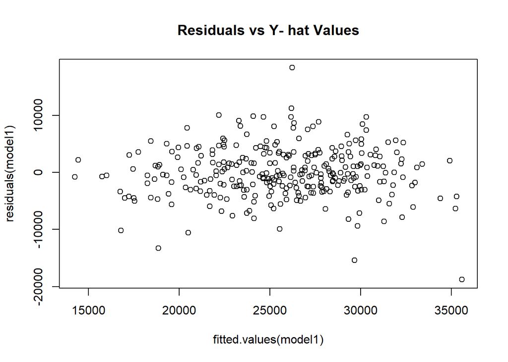

```r
plot(residuals(model1) ~fitted.values(model1), main="Residuals vs Y- hat Values")
```

With this plot we hope to evaluate the assumption of equal variance and linearity assumption. The spread appears to be scattered above and below zero equally and there appears to be no pattern and so the assumption of equal variance and linearity is met. There are outliers, but there doesn’t seem to be any other inadequacies base of this plot.

## 1g. Find the AIC values for model1, model2, model3, and model4. Which model does AIC pick as the best? Did you expect this? Explain briefly.

```r
extractAIC(model1)
```

```
## [1]   15.000 5051.576
```

```r
extractAIC(model2)
```

```
## [1]   14.000 4643.606
```

```r
extractAIC(model3)
```

```
## [1]   13.000 4643.004
```

```r
extractAIC(model4)
```

```
## [1]   11.000 4648.191
```

## 1h(i). Do you feel that any of your X variables that are in model3 suffer from possible bias from a limited sampling region? Demonstrate and comment on why or why not they may suffer from this.

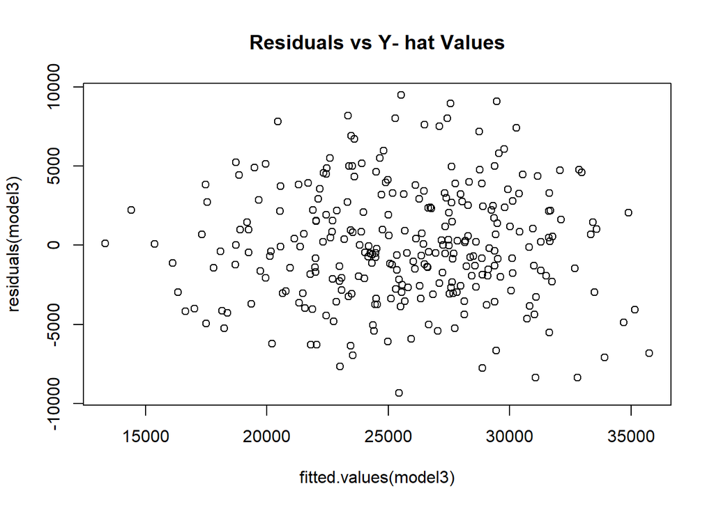

```r
plot(residuals(model3) ~fitted.values(model3), main="Residuals vs Y- hat Values")
```

Because we have fairly equal variance and some what wide spread, I think the X variables do not suffer from bias from a limited sampling region.

## 1h(ii). Comment on whether you feel your model3 suffers from bias due to omitted variables. Explain why or why not you think this.

Yes, while there are enough variables to make these models significant, there may seem to be variables would make the standard errors smaller and the R^2 values could be a littler larger.